# PROJECT-3 slides

### Crafting An Engaging Reddit Post: A FiveThirtyEight Pitch

#### Ben Shaver, Data Scientist

#### benpshaver@gmail.com

Reddit is an internet giant. In September 2017, 1.575 billion unique users visited the site.

Every day, thousands of users contribute, view, or engage with news stories, memes, and discussions.

The question we'd like to answer is: what makes a great Reddit post?

Using Python's available web scraping and data science packages, I've analyzed tens of thousands of unique Reddit posts.

I'll walk through my analysis and present a pitch for a great FiveThirtyEight post.

[(Source)](https://www.statista.com/statistics/443332/reddit-monthly-visitors/)

### Import Statements, etc.

```python
import requests
from bs4 import BeautifulSoup
import re
import pandas as pd
import seaborn as sns
import matplotlib.pyplot as plt
import numpy as np
from time import sleep
import datetime
import random
import string
import os

# %matplotlib inline

#Set the seed so we can get that sweet sweet reproducibility
np.random.seed(513)

plt.rcParams['figure.figsize'] = (10.0, 8.0)

plt.style.use(['fivethirtyeight'])
```

### Web Scraping 1.0

##### Function Definitions

```python
foo = "author = elem['data-author']\
                subreddit = elem['data-subreddit']\
                ID = elem['id']\
                timestamp = elem['data-timestamp']\
                data_url = elem['data-url']\
                permalink = elem['data-permalink']\
                rank = elem['data-rank']\
                comments = elem['data-comments-count']\
                score = elem['data-score']\
                crossposts = elem['data-num-crossposts']\
                domain = elem['data-domain']\
                context = elem['data-context']\
                r_type = elem['data-type']\
                full_name = elem['data-fullname']\
                whitelist = elem['data-whitelist-status']\
                auth_fullname = elem['data-author-fullname']\
                title".split()
bar = [foo[x] for x in range(0,len(foo),3)] + ['elapsed', 'time_scraped','method']
```

```python
def parse_reddit(URL=None, html=None, scrape_method=None):
    df = pd.DataFrame(columns=bar)
    html = requests.get(URL, headers = {'User-agent': ''.join(random.choices(string.ascii_lowercase + string.digits, k=7))})
    if html.status_code != 200:
        print("Error in http request")
        if html.status_code == 429:
            print("-- Too many requests")
        return(df)

    html_doc = html.text
    soup = BeautifulSoup(html_doc, 'lxml')
    soup = soup.find('div', {'id': 'siteTable'})

    for elem in soup.find_all('div', {'class': re.compile(' thing id')}):
        author = elem['data-author']
        subreddit = elem['data-subreddit']
        ID = elem['id']
        timestamp = elem['data-timestamp']
        data_url = elem['data-url']
        permalink = elem['data-permalink']
        rank = elem['data-rank']
        comments = elem['data-comments-count']
        score = elem['data-score']
        crossposts = elem['data-num-crossposts']
        domain = elem['data-domain']
        context = elem['data-context']
        r_type = elem['data-type']
        full_name = elem['data-fullname']
        whitelist = elem['data-whitelist-status']
        auth_fullname = elem['data-author-fullname']
        title = elem.find('a', {'data-event-action': 'title'}).text
        elapsed = elem.find('time', {'class': 'live-timestamp'}).text
        time_scraped = datetime.datetime.today()
        method = scrape_method
        df.loc[len(df)] = [author, subreddit, ID, timestamp, data_url, permalink, rank, comments, score, crossposts, domain,
                           context, r_type, full_name, whitelist, auth_fullname, title, elapsed, time_scraped, method]
    return(df)
```

```python
def reddit_url_generator(ID):
    ID = ID[6:]
    return('https://www.reddit.com/?count=25&after=' + ID)
```

#### Web Scraping the Front Pages

On the front page of Reddit, trending posts are organized according to rank. These come from many different subreddits.

We'll iterate page-by-page down the ranks and grab metadata from 25 posts at a time.

```python
reddit_df = parse_reddit('https://www.reddit.com', scrape_method = 'front')
print(reddit_df.shape)
for t in range(1):
    try:
        URL = reddit_url_generator(reddit_df.loc[reddit_df.index.max(), 'ID'])

    except:
        print("Error generating URL...")
        URL = reddit_url_generator(reddit_df.loc[len(reddit_df) -1,'ID'])

    try:
        reddit_df = reddit_df.append(parse_reddit(URL, scrape_method = 'front'), ignore_index = True)
    except:
        pass
    if t % 80 == 0:
        print("Saving to csv...")
        print("Dataframe has " + str(reddit_df.shape[0]) + " rows")
        reddit_df.dropna(how='all', inplace=True)
        reddit_df.drop_duplicates(inplace=True)
        reddit_df.to_csv('reddit_' + str(t) + '.csv')
        try:
            os.remove('reddit_' + str(t-80) + '.csv')
        except:
            pass
print(reddit_df.shape)
```

```
(25, 20)
Saving to csv...
Dataframe has 50 rows
(50, 20)
```

#### Web Scraping Random Pages

Reddit provides an easy way to access a random subreddit. By passing www.reddit.com/r/random to our web scraping function, we can perform cluster random sampling of Reddit posts.

```python
random_df = parse_reddit('https://www.reddit.com/r/random', scrape_method='random')

for p in range(1):
    try:
        random_df = random_df.append(parse_reddit('https://www.reddit.com/r/random', scrape_method='random'))
    except:
        pass

    for t in range(4):

        try:
            URL = reddit_url_generator(random_df.loc[random_df.index.max(), 'ID'])
            # This method is more robust I believe.
        except:
            print("Error generating URL...")
            URL = reddit_url_generator(random_df.loc[len(random_df) -1,'ID'])

        try:
            random_df = random_df.append(parse_reddit(URL, scrape_method='random'), ignore_index = True)
        except:
            pass
    if p % 20 == 0:
        print("Saving to csv...")
        print("Dataframe has " + str(random_df.shape[0]) + " rows")
        random_df.dropna(how='all', inplace=True)
        random_df.drop_duplicates(inplace=True)
        random_df.to_csv('random_' + str(p) + '.csv')
        try:
            os.remove('random_' + str(p-20) + '.csv')
        except:
            pass
print(random_df.shape)
```

```
Saving to csv...
Dataframe has 153 rows
(153, 20)
```

### Importing all CSVs

```python
df = pd.DataFrame(columns = bar)
for x in os.listdir('.'):
    if '.csv' in x:
        try:
            df = df.append(pd.read_csv(x, encoding='latin1'), ignore_index=True)
        except:
            print("Error appending CSV files in working directory")
df = df.reset_index()[bar]

df.dropna(how='any', inplace = True)
df.drop_duplicates(inplace = True)

df.to_csv('reddit_df_archive.csv')
```

### Data Cleaning

```python
reddit_df = df # Piping in whatever dataframe we've ended up with from above.

reddit_df.drop_duplicates(inplace=True)
reddit_df.dropna(how='all', inplace=True)

int_cols = ['rank','comments','score','crossposts']

reddit_df['timestamp'] = reddit_df['timestamp'].astype(dtype = 'int64')

for col in int_cols:
    reddit_df[col]  = reddit_df[col].astype(int)
```

```python
def time_handler(timestamp):
    try:
        return(datetime.datetime.utcfromtimestamp(timestamp / 1000))
    except:
        # if there is a timestamp error, set timestamp to Jan 1, 1970: The beginning of time!
        return(datetime.datetime.utcfromtimestamp(0))


reddit_df['timestamp'] = reddit_df['timestamp'].apply(time_handler)
```

```python
just_bool  = reddit_df['elapsed'].apply(lambda x: 'just' in x)
hours_bool = reddit_df['elapsed'].apply(lambda x: 'hour' in x)
minutes_bool = reddit_df['elapsed'].apply(lambda x: 'minute' in x)
days_bool = reddit_df['elapsed'].apply(lambda x: 'day' in x)
months_bool = reddit_df['elapsed'].apply(lambda x: 'month' in x)
weeks_bool = reddit_df['elapsed'].apply(lambda x: 'week' in x)
```

```python
reddit_df.loc[just_bool,'elapsed'] = reddit_df.loc[just_bool,'elapsed'].apply(lambda x: 0)

reddit_df.loc[hours_bool,'elapsed'] = reddit_df.loc[hours_bool,'elapsed'].apply(lambda x: int(x.split()[0]) * 60)

reddit_df.loc[minutes_bool,'elapsed'] = reddit_df.loc[minutes_bool,'elapsed'].apply(lambda x: int(x.split()[0]))

reddit_df.loc[days_bool,'elapsed'] = reddit_df.loc[days_bool,'elapsed'].apply(lambda x: int(x.split()[0]) * 24 * 60)

reddit_df.loc[months_bool,'elapsed'] = reddit_df.loc[months_bool,'elapsed'].apply(lambda x: int(x.split()[0]) * 24 * 60 * 30)

reddit_df.loc[weeks_bool,'elapsed'] = reddit_df.loc[weeks_bool,'elapsed'].apply(lambda x: int(x.split()[0]) * 24 * 60 * 7)
```

```python
reddit_df['time_scraped'] = pd.to_datetime(reddit_df['time_scraped'])
reddit_df['time_elapsed'] = reddit_df['time_scraped'] - reddit_df['timestamp']

reddit_df['elapsed'] = reddit_df['elapsed'].astype(int)
```

```python
reddit_df['method'] = reddit_df['method'].apply(lambda x: 'front' if 'front' in x else 'random')
```

```python
reddit_df.shape
```

```
(207995, 21)
```

```python
reddit_df['ID'].nunique()
```

```
36574
```

#### Consolidating Duplicates

If a post is sampled twice, I want to preserve the best (minimum) rank it achieved, but the max number of comments, score, crossposts, etc.

If a post is sampled randomly and by scraping the front pages, let it count as being scraped from front pages.

Note that `'front' < 'random'` in Python.

```python
agg_funcs = {'rank': min, 'comments': max, 'score': max, 'crossposts': max,
             'elapsed': max, 'timestamp': max, 'time_elapsed': max, 'method': min}
```

```python
reddit_df = reddit_df.groupby(by=['title','ID', 'subreddit','data_url', 'permalink', 'domain',
                                  'context', 'r_type', 'full_name', 'whitelist',
                                  'auth_fullname', 'author']).agg(agg_funcs)
reddit_df = reddit_df.reset_index()
```

```python
reddit_df['method'].value_counts()
```

[output not shown]

#### Further Cleaning

Many recognizable websites are commonly linked to from Reddit. These include YouTube, Instagram, the New York Times, and, of course, imgur.

Additionally, Reddit provides image and video hosting of its own. We'll consolidate some of these domains so they fall into sensible categories for analysis.

```python
def domain_handler(domain):
    if domain[:4] == 'self':
        # These are your basic reddit post with text. Not a link, image, etc.
        return('reddit_text')
    if 'youtu' in domain:
        return('YouTube')
    if 'imgur' in domain:
        return('imgur')
    if domain == 'i.redd.it':
        return('reddit_image')
    if domain == 'v.redd.it':
        return('reddit_video')
    if domain == 'np.reddit.com':
        # If link is a 'non-participating' reddit link, count it as a regular link to elsewhere on reddit.
        return('reddit.com')
    else:
        return(domain)


reddit_df['domain'] = reddit_df['domain'].apply(domain_handler)
```

### EDA and Visualizations

#### Most Common Subreddits on the Front Page

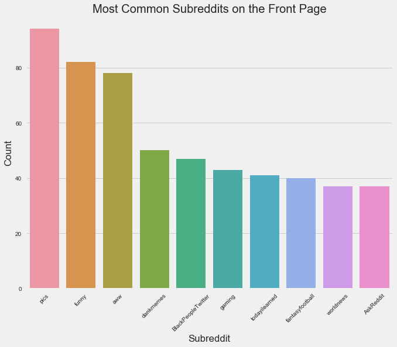

```python
_ = plt.show()
```

#### Most Common Randomly Sampled Subreddits

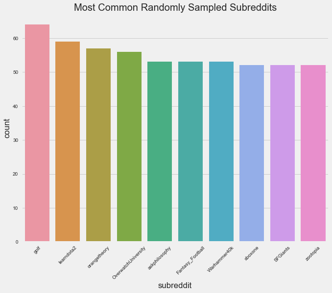

```python
_ = plt.show()
```

#### Most Common Domains on Front Page

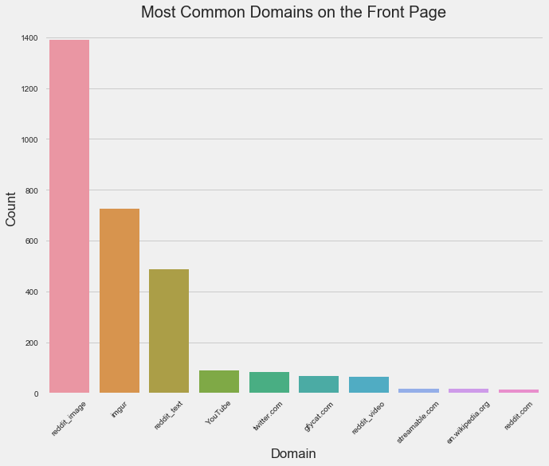

```python
plt.show()
```

#### Most Common Domains Across the Dataset

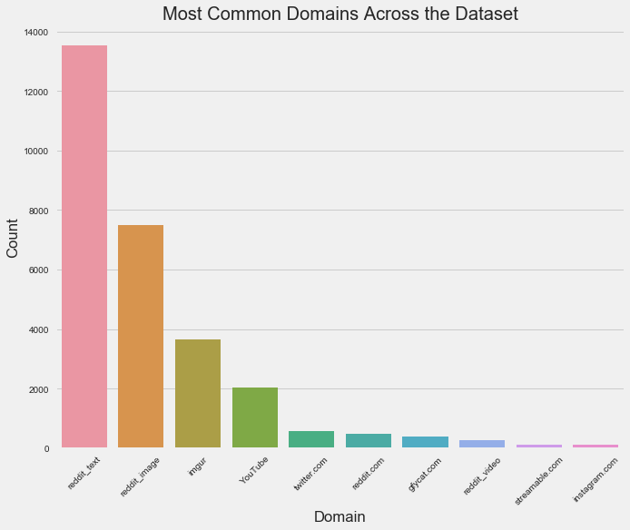

```python
_ = plt.show()
```

#### Is Reddit a Circlejerk? Yes and no.

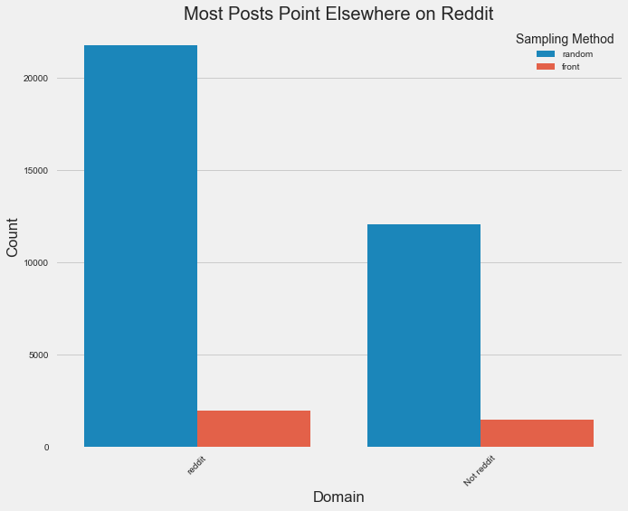

```python
_ = plt.show()
```

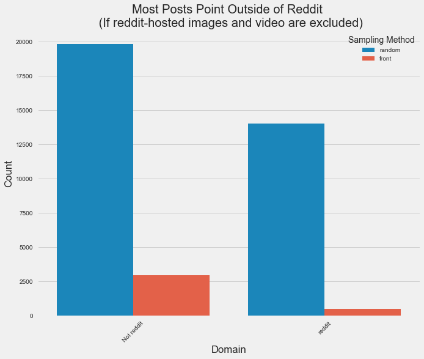

```python
_ = plt.show()
```

#### Which Subreddits Tend to Have Posts with the Most Comments? The Highest Scores?

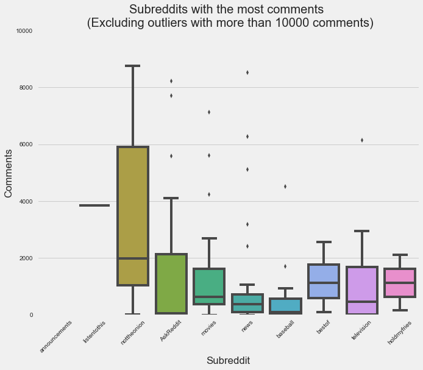

```python
_ = plt.show()
```

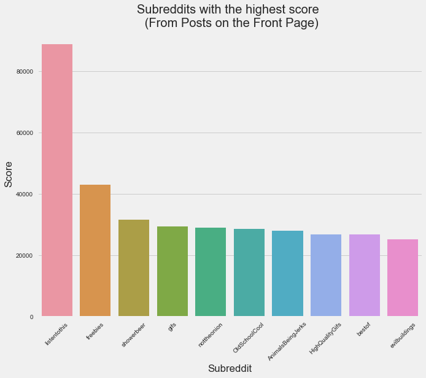

```python
_ = plt.show()
```

#### What is the relationship between number of comments and score?

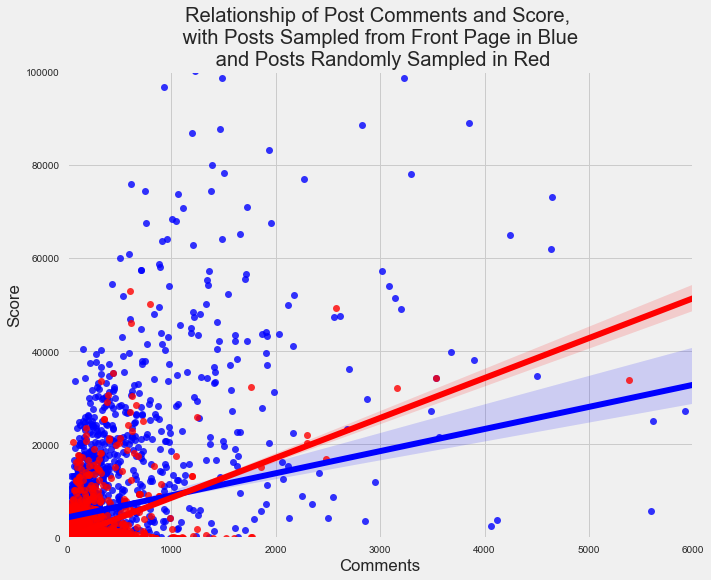

```python
_ = plt.show()
```

#### What Domains Get the Most Comments?

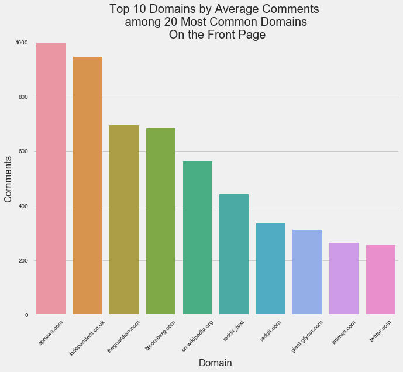

```python
_ = plt.show()
```

#### What is 'context,' anyway? -- Its nothing!

```python
reddit_df['context'].value_counts()
```

```
listing    37318
Name: context, dtype: int64
```

#### Can 'whitelist' tell us anything?

```python
reddit_df['whitelist'].value_counts()
```

```
all_ads             33617
promo_specified      1910
promo_adult           541
house_only            407
no_ads                398
promo_adult_nsfw      354
promo_all              91
Name: whitelist, dtype: int64
```

It appears 'whitelist' determines what ads are shown to users.

Its not clear that whitelist status can be controlled or affected by the reddit user. (Or known before posting.) Therefore, while it may be interesting to explore, we probably shouldn't include it as a variable if we're interesting in predicting how well a reddit post performs.

##### Comments by Whitelist Status

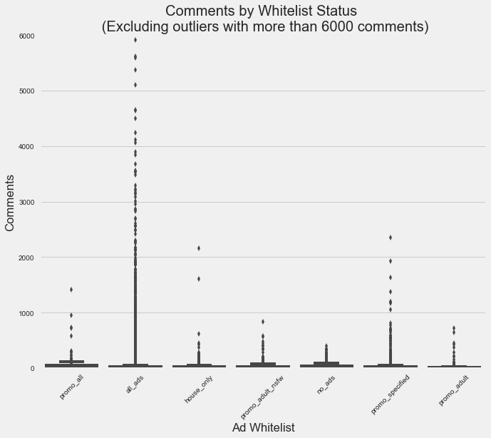

```python
_ = plt.show()
```

##### Score by Whitelist Status

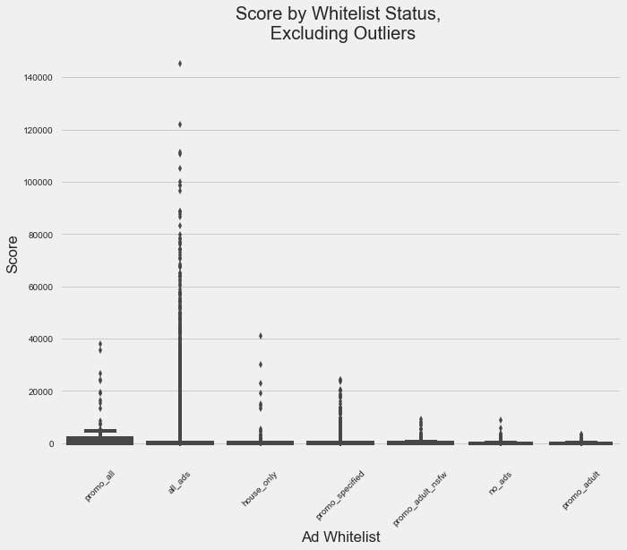

```python
plt.show()
```

#### Exploratory NLP

##### Most Common Words in Titles

```python
word_counts.head(10)
```

|  | Word Count |
| --- | --- |
| halloween | 1202 |
| new | 1136 |
| just | 888 |
| like | 829 |
| time | 651 |
| game | 648 |
| 2017 | 571 |
| help | 553 |
| post | 504 |
| people | 495 |

The web scraping for this pitch was conducting during Halloween. For the full FiveThirtyEight feature, web scraping would be conducted over a longer period in order to reduce noise.

##### Most Distinctive Words in Titles

```python
word_dist.head(10)
```

|  | Word Distinctiveness |
| --- | --- |
| halloween | 370.697098 |
| new | 261.952495 |
| just | 222.787317 |
| like | 201.936826 |
| happy | 176.873745 |
| game | 175.458653 |
| help | 172.302847 |
| time | 172.252634 |
| 2017 | 153.199725 |
| best | 140.982790 |

### Modeling

#### Drop Uninformative Columns

We've got a lot of metadata. Not all of it will be useful.

Rank, score, and number of comments are possible metrics of post success.

We want to model post success using the post's title, its subreddit, and the domain it links to.

For now, lets only model based on our randomly sampled Reddit data. It is representative of all Reddit posts.

```python
df = reddit_df.loc[reddit_df['method'] == 'random',['title', 'subreddit', 'domain', 'rank',
                'comments', 'score']]
```

#### Make Target Variable and Train Test Split

```python
df['target'] = [1 if x > np.median(df['comments']) else 0  for x in df['comments']]
df.drop(['comments','score','rank'], axis= 1, inplace=True)
```

For now, let's try a simple binary classification: whether a random Reddit post has above or below the median number of comments.

Using rank or score is cheating.

```python
df = pd.get_dummies(df, columns=['subreddit','domain'])

from sklearn.model_selection import train_test_split

X_train, X_test, y_train, y_test = train_test_split(df.drop('target', axis = 1),df['target'], test_size = .3, random_state = 513)
```

#### NLP

```python
from sklearn.feature_extraction.text import TfidfVectorizer, CountVectorizer
from scipy.sparse import csr_matrix

# Initialize vectorizer
tf = TfidfVectorizer(max_features=1000, stop_words='english')

# Fit vectorizer on title column from training data and transform
sparse_matrix = tf.fit_transform(X_train['title'])
X_train_words = pd.DataFrame(sparse_matrix.todense(), columns=tf.get_feature_names())

X_train = X_train.reset_index().join(X_train_words, rsuffix='_nlp')
```

```python
X_train.loc[X_train['title'].apply(lambda x: 'halloween' in x), ['title','halloween']].head()
```

|  | title | halloween |
| --- | --- | --- |
| 5 | My wife and I went as r/forwardsfromgrandma (a... | 0.202829 |
| 1113 | Tom Brady's halloween costume | 0.418234 |
| 2246 | they love halloween | 0.612012 |
| 2397 | I (also) dressed as our boy for halloween | 0.411272 |
| 2554 | Went as Brent Burns for halloween | 0.562333 |

```python
# Fit vectorizer on title column from test data and transform
sparse_matrix = tf.transform(X_test['title'])
X_test_words = pd.DataFrame(sparse_matrix.todense(), columns=tf.get_feature_names())

X_test = X_test.reset_index().join(X_test_words, rsuffix='_nlp')
```

```python
X_test.loc[X_test['title'].apply(lambda x: 'halloween' in x), ['title','halloween']].head()
```

|  | title | halloween |
| --- | --- | --- |
| 1519 | Lebron James dressed as Pennywise for halloween | 0.397384 |
| 1866 | Overhaul cosplay I did for halloween. I dunno,... | 0.208847 |
| 2080 | Heading uptown dressed as Hamilton cast (hallo... | 0.393755 |
| 2607 | This is halloween | 1.000000 |
| 3033 | Doodle of halloween costume doge. A bit late, ... | 0.319607 |

```python
# Reset indices back to the original so that indices in X_train and y_train match, for example. If necessary.
X_train = X_train.set_index('index')
X_test = X_test.set_index('index')

# Drop title columns since we've vectorized them.
X_train.drop('title', axis=1, inplace=True)
X_test.drop('title', axis=1, inplace=True)
```

#### Logistic Regression

```python
from sklearn.linear_model import LogisticRegression

lm = LogisticRegression(C=10, penalty='l1')
lm.fit(X_train, y_train)
print("Training accuracy: " + str(lm.score(X_train, y_train)))
print("Testing accuracy: " + str(lm.score(X_test, y_test)))
```

```
Training accuracy: 0.769409380673
Testing accuracy: 0.668439716312
```

Lets try and see if we can't tune our hyperparameters for better test set performance:

```python
from sklearn.model_selection import GridSearchCV

param_grid_logreg = {'penalty':['l1','l2'], 'C':[.001, .01, .1, 1, 10, 100]}

lm_gs = GridSearchCV(lm, param_grid_logreg, n_jobs = -1)
lm_gs.fit(X_train, y_train)
lm_gs.best_estimator_

LogisticRegression(C=1, class_weight=None, dual=False, fit_intercept=True,
          intercept_scaling=1, max_iter=100, multi_class='ovr', n_jobs=1,
          penalty='l2', random_state=None, solver='liblinear', tol=0.0001,
          verbose=0, warm_start=False)
```

```
LogisticRegression(C=1, class_weight=None, dual=False, fit_intercept=True,
          intercept_scaling=1, max_iter=100, multi_class='ovr', n_jobs=1,
          penalty='l2', random_state=None, solver='liblinear', tol=0.0001,
          verbose=0, warm_start=False)
```

```python
lm_gs.score(X_test, y_test)
```

```
0.67828999211977936
```

Logistic regression gets us to 68% accuracy. If it would have performed better, we'd happily use it and interpret it.

#### Decision Tree Model

A decision tree model is basically a computer-generated flow chart that describes our data.

If it works, its an easily interpreted model.

```python
from sklearn.tree import DecisionTreeClassifier
tree = DecisionTreeClassifier()

tree.fit(X_train, y_train)
print(tree.score(X_train, y_train))
print(tree.score(X_test, y_test))
```

```
0.977016350501
0.606565457413
```

Our next choice for a nicely interpretable model doesn't do so well either.

It performs well on the training set, but not on the test set. It could be overfit.

Lets hyperparameter tune. If we can reduce our model overfitting, we might be able to "close the gap" between our training set and test set accuracy scores.

```python
# param_grid_tree = {'max_depth':[50, 500, 1000], 'min_samples_split':[6, 20]}

# tree_gs = GridSearchCV(tree, param_grid_tree, n_jobs = -1)
# tree_gs.fit(X_train, y_train)
# tree_gs.best_estimator_

# DecisionTreeClassifier(class_weight=None, criterion='gini', max_depth=1000,
#             max_features=None, max_leaf_nodes=None,
#             min_impurity_decrease=0.0, min_impurity_split=None,
#             min_samples_leaf=1, min_samples_split=6,
#             min_weight_fraction_leaf=0.0, presort=False, random_state=None,
#             splitter='best')
```

```python
# print(tree_gs.score(X_train, y_train))
# print(tree_gs.score(X_test, y_test))
```

#### Random Forest

```python
from sklearn.ensemble import RandomForestClassifier
```

```python
forest = RandomForestClassifier(max_depth=100, max_features='log2', n_estimators=50)
forest.fit(X_train, y_train)
print("Training accuracy: " + str(forest.score(X_train, y_train)))
print("Testing accuracy: " + str(forest.score(X_test, y_test)))
```

```
Training accuracy: 0.804626815265
Testing accuracy: 0.615089136216
```

The random forest model doesn't really improve on our previous models!

### Limitations and Steps Forwards

#### Sampling Method

Sampling from the front pages of Reddit can be useful to determine which posts succeed, but we are systematically undersampling unsuccessful posts.

Sampling randomly is easy and simple, but we are performing cluster random sampling. For every subreddit selected, we sample many entries.

Other subreddits aren't sampled at all.

Instead, sample exhaustively from [this list](https://www.reddit.com/r/ListOfSubreddits/wiki/listofsubreddits) of subreddits with over 50,000 subscribers.

#### Sampling Post Content

The *content* of a post is what truly determines its success. We must move past metadata.

If a post is text, or links to text, we can perform NLP on it. Otherwise, we are limited by computational capacity and storage to perform image processing on each image post.

Interesting Reddit analysis would be network analysis, or the types of Natural Language Processing that made ["Dissecting Trump's Most Rabid Online Following"](https://fivethirtyeight.com/features/dissecting-trumps-most-rabid-online-following/) a sucessful feature.

These articles don't require analyzing post content.

#### Modeling Reddit Post Performance Is Hard.

#### So, in the spirit of Hot Dog / Not a Hot Dog:

Looking at the most popular subreddits, we can classify them with a very high level of confidence according to whether or not a post is likely to be an image post.

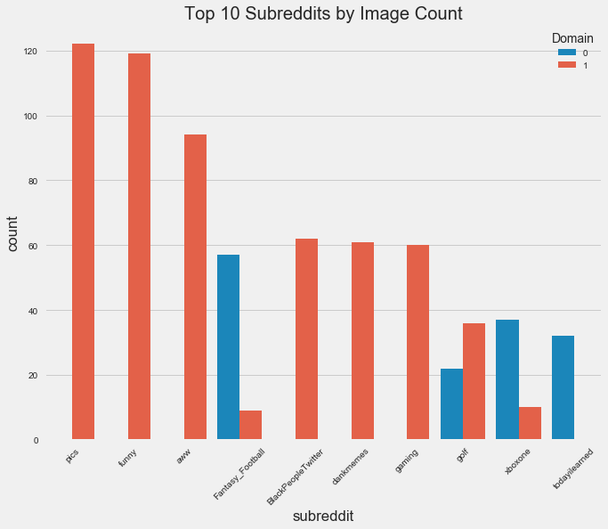

```python
_ = plt.show()
```

```python
df2 = pd.get_dummies(df2, 'subreddit')
X_train, X_test, y_train, y_test = train_test_split(df2.drop(['domain','score'], axis = 1), df2['domain'])

logreg = LogisticRegression()
logreg.fit(X_train, y_train)
logreg.score(X_test, y_test)
```

```
0.91712707182320441
```

Sometimes EDA is enough.

Or, an attractive feature piece can be written using EDA and 'exploratory modeling'